# Gender barriers in farm technology adoption among small-holder vegetable farmers in Ormoc City, Leyte

Author

ViSERDAC

Published

May 10, 2026

# 1 Attachments

**Note**

Copies of the Figures presented in this report are available using the links below. All the files can be accessed in the Google drive folder.

1. [Plots](https://drive.google.com/drive/folders/1I2PFRfb5vYPw0jx2PcIQYMpe1DO943EU?usp=sharing)
2. [Google Drive](https://drive.google.com/drive/folders/1cyLa0hL07qb-IDCc-xvLGZaxpfWk_dtS?usp=sharing)

# 2 Objective 1: Identify and describe the farm technologies currently used by smallholder vegetable farmers in Ormoc City over the past ten years from 2014 to 2024

### Sociodemographic profile

**NoteInterpretations**

- **Age**
  - Female median age: 41 (IQR: 35–50)
  - Male median age: 40 (IQR: 30–50)
  - Both groups are middle‑aged, with women slightly older on average. This suggests similar generational exposure to technology, but women may face age‑related constraints earlier.
- **Civil Status**
  - Majority of both groups are married (64% of women, 82% of men). Women show more diversity: 15% live‑in, 5% separated, 5% widowed.
  - Men are almost exclusively married or single.
  - Women’s broader civil status distribution may affect decision‑making power and resource access, especially for widowed or separated women.
- **Ethnicity**
  - Predominantly Bisaya (90% women, 97% men). Women have more representation from Waray (10%).
  - Ethnic composition is largely homogeneous, but women’s slightly more diverse background may influence cultural norms in adoption.
- **Education**
  - Elementary education dominates (49% women, 56% men). High school is the second most common (38% women, 33% men).
  - Women show slightly higher attainment at college (7.7% vs 4.9%) and graduate level (5.1% vs 0%). Men have more vocational/ALS representation.
  - Overall, both groups have modest educational attainment, but women show a small edge in higher education, which could support adoption if resource barriers are addressed.
- **Household headship**
  - 100% of men are household heads. Only 33% of women are household heads; 67% are not.
  - This is a major gender disparity: men hold formal decision‑making authority, while most women lack it, limiting their autonomy in adopting technologies.
- **Household size**
  - Women: median 5 (IQR: 3–6). Men: median 4 (IQR: 3–5).
  - Women’s households are slightly larger, implying greater domestic responsibilities that may compete with technology adoption.
- **Income**
  - Non‑farm income: Women report higher medians (₱24,000 vs ₱8,000).
  - On‑farm income: Men slightly higher (₱50,000 vs ₱43,000).
  - Off‑farm income: Women higher (₱24,000 vs ₱6,000).
  - Women diversify income sources more, while men rely more on farm income. This suggests women may be more risk‑averse and constrained by time, balancing multiple income streams.
- **Land characteristics**
  - Land area: Men hold larger plots (median 0.75 ha vs 0.50 ha).
  - Land type: Both groups mostly lowland (≈60%). Women: more sloping land (36%). Men: more upland (11%).
  - Men’s larger landholdings and upland plots may give them more leverage in adopting technologies, while women’s smaller and sloping plots may limit mechanization.

```r
df |>
  select(
    sex:hh_head,
    hh_size,
    nonfarm_income,
    onfarm_income_yr,
    offfarm_income_yr,
    area_ha,
    land_type,
    -status
  ) |>
  tbl_summary(
    by = sex,
    statistic = list(all_categorical() ~ "{p}% (n = {n})"),
    type = list(hh_head ~ "categorical"),
    missing = "no",
    label = list(
      age ~ "Age",
      civil_status ~ "Civil status",
      ethnicity ~ "Ethnicity",
      educ_attainment ~ "Educational attainment",
      hh_head ~ "Household head",
      hh_size ~ "Household size",
      nonfarm_income ~ "Non-farm income",
      onfarm_income_yr ~ "On-farm income",
      offfarm_income_yr ~ "Off-farm income",
      area_ha = "Land area (ha)",
      land_type = "Land type"
    )
  ) |>
  bold_labels() |>
  as_kable_extra(linesep = "") |>
  kable_minimal() |>
  kable_styling(
    full_width = F,
    fixed_thead = T,
    bootstrap_options = c("striped", "hover", "condensed", "responsive")
  )
```

| Characteristic | Female N = 39 | Male N = 61 |
| --- | --- | --- |
| Age | 41 (35, 50) | 40 (30, 50) |
| Civil status |  |  |
| live in | 15% (n = 6) | 6.6% (n = 4) |
| married | 64% (n = 25) | 82% (n = 50) |
| separated | 5.1% (n = 2) | 0% (n = 0) |
| single | 10% (n = 4) | 11% (n = 7) |
| widowed | 5.1% (n = 2) | 0% (n = 0) |
| Ethnicity |  |  |
| bisaya | 90% (n = 35) | 97% (n = 59) |
| cebuano | 0% (n = 0) | 1.6% (n = 1) |
| waray | 10% (n = 4) | 1.6% (n = 1) |
| Educational attainment |  |  |
| ALS | 0% (n = 0) | 1.6% (n = 1) |
| College | 7.7% (n = 3) | 4.9% (n = 3) |
| Elementary | 49% (n = 19) | 56% (n = 34) |
| Graduate course | 5.1% (n = 2) | 0% (n = 0) |
| Highschool | 38% (n = 15) | 33% (n = 20) |
| Senior highschool | 0% (n = 0) | 1.6% (n = 1) |
| Vocational course | 0% (n = 0) | 3.3% (n = 2) |
| Household head |  |  |
| No | 67% (n = 26) | 0% (n = 0) |
| Yes | 33% (n = 13) | 100% (n = 61) |
| Household size | 5.00 (3.00, 6.00) | 4.00 (3.00, 5.00) |
| Non-farm income | 24,000 (13,200, 49,180) | 8,000 (5,000, 30,000) |
| On-farm income | 43,000 (20,000, 95,000) | 50,000 (30,000, 100,000) |
| Off-farm income | 24,000 (10,000, 50,000) | 6,000 (5,000, 29,000) |
| Land area (ha) | 0.50 (0.25, 0.75) | 0.75 (0.31, 0.75) |
| Land type |  |  |
| Lowland | 58% (n = 21) | 61% (n = 37) |
| Sloping/bakilid | 36% (n = 13) | 28% (n = 17) |
| Upland/ Bukid | 5.6% (n = 2) | 11% (n = 7) |

<sup>1</sup> Median (Q1, Q3); % (n = n)

### Crops planted

**NoteInterpretation**

- Women diversify more, planting a wider range of crops, though in smaller quantities. While men specialize more, concentrating on cabbage and Chinese cabbage.
- Female farmers
  - Chinese cabbage (33%) and cabbage (22%) dominate women’s crop choices.
  - Women show greater crop diversity: aside from leafy greens, they cultivate sweet pepper, chilli, beans, coconut, tomato, radish, onion, eggplant, and other vegetables in smaller proportions.
- Male farmers
  - Chinese cabbage (42%) and cabbage (34%) are even more dominant among men, accounting for three‑quarters of their crop choices.
  - Men’s crop portfolio is less diverse: aside from leafy greens, only small shares go to sweet pepper, tomato, eggplant, chilli, coconut, and ombok.

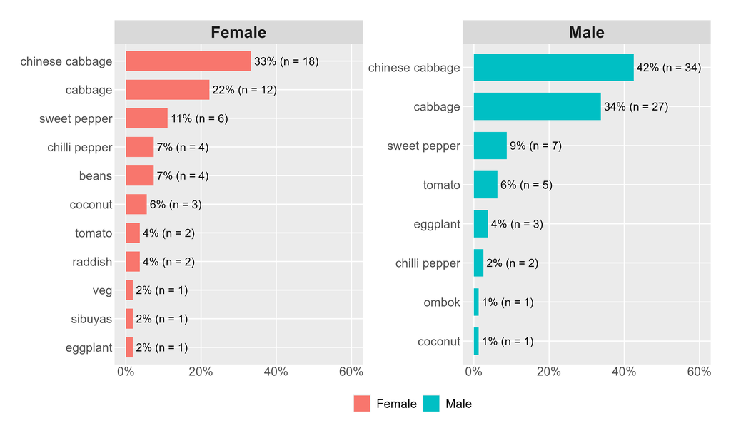

```r
crops_planted_dta <-
  df |>
  select(sex, crops_planted) |>
  str_separate(var_name = crops_planted) |>
  mutate(
    crops_planted = case_when(
      str_detect(crops_planted, "chinese") ~ "chinese cabbage",
      str_detect(crops_planted, "chili pepper") ~ "chilli pepper",
      str_detect(crops_planted, "sweet pepper") ~ "sweet pepper",
      str_detect(crops_planted, "pepper") ~ "chilli pepper",
      str_detect(crops_planted, "coconut") ~ "coconut",
      TRUE ~ crops_planted
    )
  )

p_crops_planted <-
  plot_pct_by_sex(
    df = crops_planted_dta,
    category_var = crops_planted,
    ncol = 2,
    x_max = 0.6
  )

## saving plot
ggsave(
  plot = p_crops_planted,
  filename = "plot/p_crops_planted.jpeg",
  width = 10,
  height = 6,
  dpi = 400,
  unit = "in"
)

## display plot
knitr::include_graphics("plot/p_crops_planted.jpeg")
```

### Farm practices

**NoteInterpretation**

- Female Farmers
  - Integrated Pest Management (IPM) is the most common training/practice area (50%).They also engage in Food Safety & Post‑Harvest (21%), Sustainable Cultural Practices (14%), and Soil & Nutrient Management (14%).
- Male Farmers
  - IPM dominates strongly (69%), showing men’s practices are heavily focused on pest control. Secondary practices include Soil & Nutrient Management (17%), Sustainable Cultural Practices (9%), and small shares in Market Literacy (3%) and Food Safety & Post‑Harvest (3%).
  - Men’s practices are more concentrated on production‑oriented topics, with limited engagement in post‑harvest and market literacy.
- Women’s engagement in post‑harvest and food safety suggests a concern for quality and household consumption, while men’s focus on IPM and soil management points to productivity and market orientation.

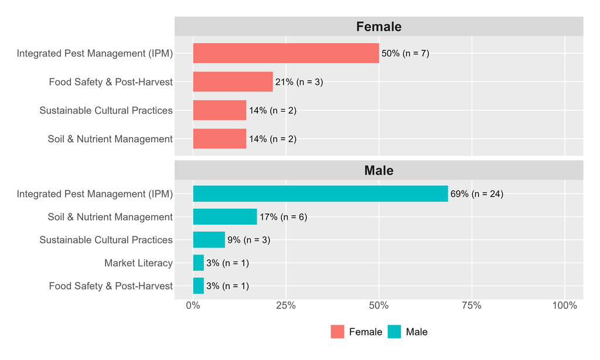

```r
p_farm_practice <- plot_pct_by_sex(df = df, category_var = category1)

## saving plot
ggsave(
  plot = p_farm_practice,
  filename = "plot/p_farm_practice.jpeg",
  width = 10,
  height = 6,
  dpi = 400,
  unit = "in"
)

## display plot
knitr::include_graphics("plot/p_farm_practice.jpeg")
```

### Farm technologies

**NoteInterpretation**

- Female Farmers
  - Crop Protection (50%) is the dominant area, showing women’s strong involvement in pest and disease management Smaller shares are spread across Soil & Water Management (12%), Protected Horticulture (12%), Plant Breeding/Propagation (12%), and Farm Mechanization (12%).
- Male Farmers
  - Crop Protection (33%) is also the largest category, but less dominant compared to women. Men show broader distribution across Protected Horticulture (19%), Plant Breeding/Propagation (19%), and Farm Mechanization (19%), with smaller shares in Soil & Water Management (5%) and Green Manuring (5%).
- Overall, women are more likely involve in crop protection, while men diversify into mechanization, breeding, and horticulture, reflecting greater access to resources, land, and decision‑making authority.
- Women’s limited presence in mechanization highlights a gender barrier in access to equipment and training, while men’s lower share in food safety/post‑harvest (from earlier results) shows a gap in quality assurance practices.
- The presence of women in multiple categories, though in small numbers, suggests interest and potential for expansion if barriers are reduced.

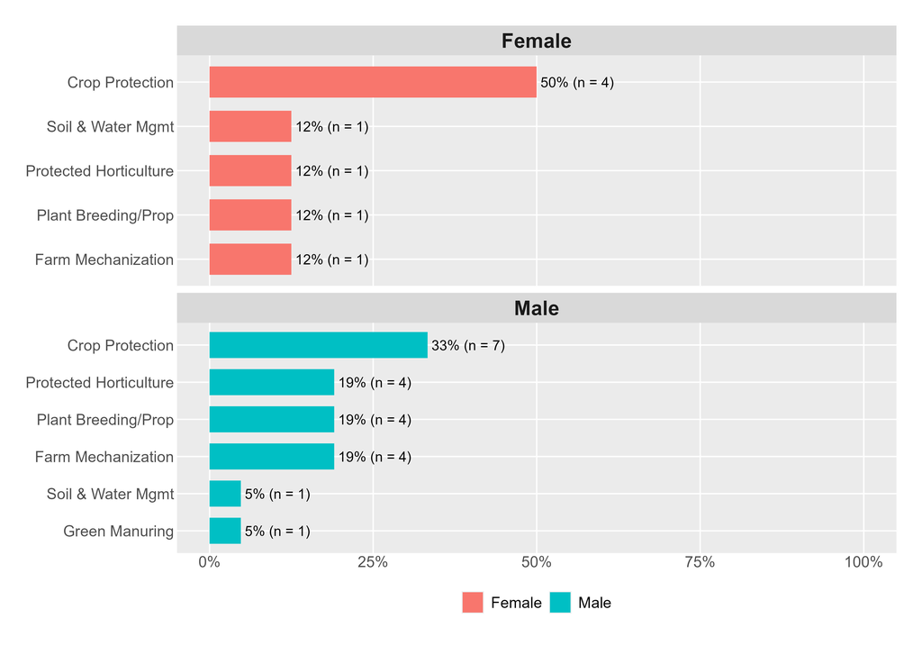

```r
p_farm_tech <- plot_pct_by_sex(df = df, category_var = category2)


## saving plot
ggsave(
  plot = p_farm_tech,
  filename = "plot/p_farm_tech.jpeg",
  width = 10,
  height = 7,
  dpi = 400,
  unit = "in"
)

## display plot
knitr::include_graphics("plot/p_farm_tech.jpeg")
```

### Source of information

**NoteInterpretation**

- Female Farmers
  - Chemical companies (21%) are the most cited source, showing women’s reliance on external suppliers for inputs and advice.
  - Other sources are evenly spread: neighbors (14%), Department of Agriculture (DA, 14%), agri‑input suppliers (14%), and other informal sources (14%). Smaller shares come from relatives, family, and local government (LGU CAO).
- Male Farmers
  - Department of Agriculture (21%) and “other” sources (21%) are the top influences. Neighbors (17%) and agri‑input suppliers (12%) also play important roles.
  - Men show broader institutional reach, citing seed companies, NGOs, internet, farmer associations, and academe (each 4%).
- Women rely more on chemical companies and personal ties (neighbors, relatives, family), reflecting limited access to formal institutions. Men rely more on DA and institutional sources, including NGOs, farmer associations, and internet, showing greater integration into formal extension systems.
- Women’s fragmented networks may limit consistent access to updated information, while men’s broader institutional ties provide more structured support.
- The absence of women citing internet or farmer associations highlights a digital and organizational participation gap.
- Women’s information sources are informal and supplier‑driven, while men’s sources are more institutional and diversified. This reflects systemic gender barriers: women’s weaker access to formal extension services and digital platforms.

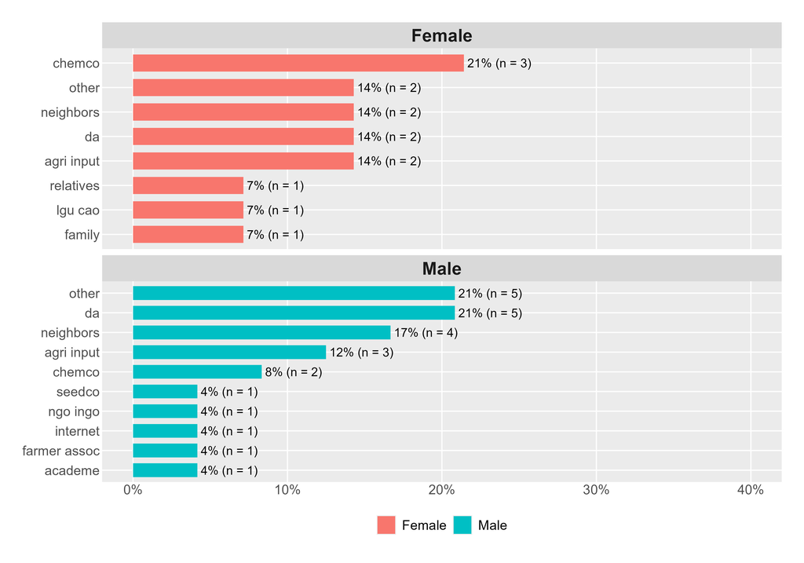

```r
info_source_dta <-
  df |>
  select(sex, starts_with("src_")) |>
  pivot_longer(
    cols = src_lgu_cao:src_other,
    names_to = "info_source"
  ) |>
  filter(value > 0) |>
  mutate(
    info_source = str_remove_all(info_source, "src_"),
    info_source = str_replace_all(info_source, "_", " ")
  ) |>
  group_by(sex, info_source) |>
  summarise(n = sum(value, na.rm = T)) |>
  ungroup() |>
  group_by(sex) |>
  pct_label(n) |>
  ungroup()

p_info_source <- plot_bar_by_sex(
  df = info_source_dta,
  category_var = info_source,
  x_max = 0.4
)


## saving plot
ggsave(
  plot = p_info_source,
  filename = "plot/p_info_source.jpeg",
  width = 10,
  height = 7,
  dpi = 400,
  unit = "in"
)

## display plot
knitr::include_graphics("plot/p_info_source.jpeg")
```

# 3 Objective 2: Analyze the socioeconomic determinants influencing technology adoption among smallholder vegetable farmers.

- Logit
  - The logit is the raw output of logistic regression. It’s the “mathematical score” the model calculates before converting it into a probability.
  - Positive logit → increases likelihood of adoption.
  - Negative logit → decreases likelihood.
  - Example: Attended training has a logit of 2.161, meaning training strongly pushes adoption upward.
- Odds Ratio
  - The odds ratio translates the logit into something easier to understand: how many times more likely adoption is when the factor is present.
  - Odds ratio > 1 → increases chance of adoption.
  - Odds ratio < 1 → decreases chance.
  - Example: New tech awareness has an odds ratio of 437.5*. That means farmers aware of new technology are over 400 times more likely to adopt compared to those unaware.
- Marginal Effects
  - Marginal effects show the change in probability (in percentage points) when a factor changes.
  - This is the most intuitive measure for non‑technical audiences.
  - Example: Attended training increases adoption probability by 10.6%, while New tech awareness increases it by 70.3%.
  - Think of it as: “If we train 10 farmers, about 1 extra farmer will adopt; if 10 farmers become aware of new technology, about 7 extra will adopt.”
- Model Fit Statistics (How good is the model?)
  - Number of observations (N=100) → sample size used.
  - AIC (86.8) & BIC (118.1) → technical measures of how well the model balances accuracy and simplicity. Lower is better.
  - R² Tjur (0.76) → tells us the model explains 76% of the variation in adoption. That’s very strong.
  - RMSE (0.25) → average prediction error. Smaller means more accurate.
  - Log Likelihood (-31.424) → another measure of fit; higher (less negative) is better.
  - F statistic (3.411) → shows the overall model is statistically significant.

**NoteSinficant predictors**

- **New Technology Awareness**
  - Logit: 6.081 ***
  - Odds Ratio: 437.5 ***
  - Marginal Effect: 0.703 ***
  - Awareness is the strongest predictor. Farmers who are aware of new technologies are vastly more likely to adopt, with a 70% higher probability. This aligns with the thesis framework: perceived usefulness and information access drive adoption.
- **Attended Training**
  - Logit: 2.161 *
  - Odds Ratio: 8.677 *
  - Marginal Effect: 0.106 **
  - Training attendance increases adoption likelihood nearly ninefold. Marginal effect shows a 10% increase in probability. This highlights the critical role of extension services and training access, especially for women who often face barriers here.
- **Perception Score**
  - Logit: 0.188 **
  - Odds Ratio: 1.206 **
  - Marginal Effect: 0.010 **
  - Positive perceptions of technology significantly increase adoption. Each unit increase in perception score raises adoption probability by about 1%. This reflects TAM’s perceived usefulness construct.
- **Practice Score**
  - Logit: 0.224 **
  - Odds Ratio: 1.251 **
  - Marginal Effect: 0.012 **
  - Actual practice experience boosts adoption. Farmers who already apply practices are more likely to adopt new technologies, reinforcing the importance of experiential learning.
- **Knowledge Score**
  - Marginally significant (+)
  - Odds Ratio: 1.141 +
  - Marginal Effect: 0.007 +
  - Knowledge contributes positively, though less strongly than perception and practice. This suggests knowledge alone is insufficient unless paired with awareness and training.
- **Organizational Membership**
  - Logit: 1.368 +
  - Odds Ratio: 3.928 +
  - Marginal Effect: 0.074
  - Membership in farmer organizations increases adoption likelihood, though significance is marginal. Networks provide information and collective support, consistent with your literature on social learning.

```r
library(margins)
library(modelsummary)

## formula
adop_socio_fxn <- as.formula(adopt ~ .)

## logistic regression with weights
model_adopt <- glm(
  formula = adop_socio_fxn,
  data = reg_df,
  family = binomial,
  weights = ifelse(adopt == 1, 77 / 23, 1),
  na.action = na.omit
)

## marginal effects
model_adopt_marginal_eff <- margins(model_adopt)

## model summary list
models_adopt <- list(
  "Logit" = model_adopt,
  "Odds Ratio" = model_adopt,
  "Marginal effects" = model_adopt_marginal_eff
)

## regression table
modelsummary(
  models_adopt,
  exponentiate = c(FALSE, TRUE, FALSE),
  stars = TRUE,
  title = "Logistic regression results showing the influence of socio-demographic factors, training, awareness, perceptions, knowledge, and practices on farm technology adoption among smallholder vegetable farmers in Ormoc City, Leyte.",
  fmt = 3,
  estimate = "{estimate} {stars}<br>({std.error})",
  statistic = NULL,
  gof_ma = c("nobs", "aic", "bic", "r2.tjur", "rmse", "F", "logLik"),
  notes = list(
    "Significance levels: + p < 0.10, * p < 0.05, ** p < 0.01, *** p < 0.001"
  ),
  coef_map = c(
    "(Intercept)" = "Constant",
    "sexMale" = "Sex (Male)",
    "age" = "Age",
    "civil_statussingle" = "Civil Status: Single",
    "educ_attainmentHigh school and higher" = "Education: High school",
    "hh_size" = "Household Size",
    "hh_org_memberYes" = "Org Membership",
    "attend_training5yrYes" = "Attended training",
    "aware_newtechYes" = "New tech awareness",
    "summ_percep" = "Perception Score",
    "summ_know" = "Knowledge Score",
    "summ_practice" = "Practice Score"
  )
)
```

Logistic regression results showing the influence of socio-demographic factors, training, awareness, perceptions, knowledge, and practices on farm technology adoption among smallholder vegetable farmers in Ormoc City, Leyte.

|  | Logit | Odds Ratio | Marginal effects |
| --- | --- | --- | --- |
| Constant | -8.792 * (3.797) | 0.000 * (0.001) |  |
| Sex (Male) | 0.877 (0.830) | 2.404 (1.996) | 0.045 (0.042) |
| Age | -0.010 (0.034) | 0.990 (0.033) | -0.001 (0.002) |
| Civil Status: Single | 1.137 (1.522) | 3.118 (4.745) | 0.065 (0.093) |
| Education: High school | -0.223 (0.812) | 0.800 (0.650) | -0.012 (0.043) |
| Household Size | 0.225 (0.227) | 1.252 (0.284) | 0.012 (0.012) |
| Org Membership | 1.368 + (0.823) | 3.928 + (3.231) | 0.074 (0.045) |
| Attended training | 2.161 * (0.925) | 8.677 * (8.028) | 0.106 ** (0.041) |
| New tech awareness | 6.081 *** (1.057) | 437.515 *** (462.305) | 0.703 *** (0.063) |
| Perception Score | 0.188 ** (0.063) | 1.206 ** (0.076) | 0.010 ** (0.003) |
| Knowledge Score | 0.132 + (0.072) | 1.141 + (0.082) | 0.007 + (0.004) |
| Practice Score | 0.224 ** (0.078) | 1.251 ** (0.097) | 0.012 ** (0.004) |
| Num.Obs. | 100 | 100 |  |
| AIC | 86.8 | 86.8 | 86.8 |
| BIC | 118.1 | 118.1 | 118.1 |
| R2 tjur | 0.76 | 0.76 | 0.76 |
| RMSE | 0.25 | 0.25 | 0.25 |
| F | 3.411 | 3.411 |  |
| Log.Lik. | -31.424 | -31.424 |  |

Significance levels: + p < 0.10, * p < 0.05, ** p < 0.01, *** p < 0.001

# 4 Objective 3: Investigate the barriers hindering the adoption of farm technologies.

Still need to find variables as barriers to adoption

## 4.1 Decision-making

### household decision-making

**NoteKey insights**

[output not shown]

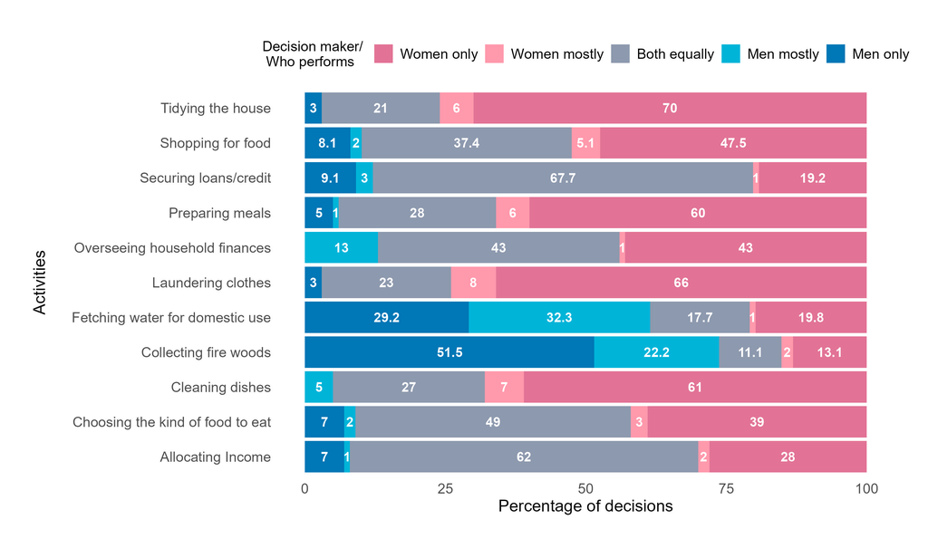

```r
p_hh_mgmt <-
  hh_mgmt_dta %>%
  group_by(activities) %>%
  mutate(pct = count / sum(count) * 100) %>%
  filter(pct != 0) %>%
  mutate(
    decision = factor(
      decision,
      levels = c(
        "Women only",
        "Women mostly",
        "Both equally",
        "Men mostly",
        "Men only"
      )
    )
  ) %>%
  ggplot(aes(y = activities, x = pct, fill = decision)) +
  geom_col() +
  # label values with percent
  geom_text(
    aes(label = round(pct, 1)),
    position = position_stack(vjust = 0.5),
    fontface = "bold",
    color = "white",
    size = 4
  ) +
  scale_fill_manual(
    values = c("#e27396", "#ff99ac", "#8d99ae", "#00b4d8", "#0077b6")
  ) +
  labs(
    x = "Percentage of decisions",
    y = "Activities",
    fill = "Decision maker/ \n Who performs"
  ) +
  theme_minimal() +
  theme(
    plot.margin = margin(1, 1, 1, 1, "cm"),
    panel.grid = element_blank(),
    legend.title = element_text(size = 12),
    legend.text = element_text(size = 12),
    axis.text.x = element_text(size = 12),
    axis.text.y = element_text(size = 12),
    axis.title.x = element_text(size = 14),
    axis.title.y = element_text(size = 14, margin = margin(r = 20)),
    legend.position = "top",
    legend.box = "horizontal"
  )

### saving plot
ggsave(
  "plot/household_management.jpeg",
  plot = p_hh_mgmt,
  width = 11,
  height = 6.5,
  dpi = 300,
  units = "in"
)

## display plot
knitr::include_graphics("plot/household_management.jpeg")
```

### 4.1.1 Farm decision-making

**NoteIntepretation**

[output not shown]

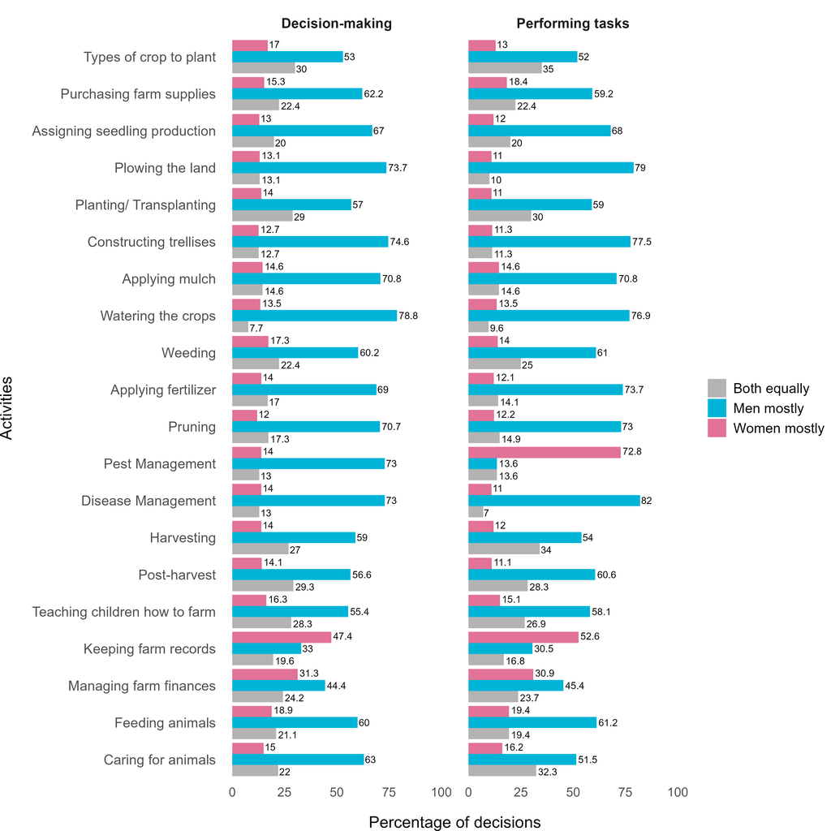

```r
## Gender Roles in Decision-Making and Performance of Vegetable Farming Tasks

activities_levels <-
  hh_farming_tasks |>
  select(activities) |>
  distinct(activities) |>
  pull(activities)


p_farming_task <-
  hh_farming_tasks |>
  mutate(
    decision_maker_bi = case_when(
      str_detect(decision_maker, "Men") ~ "Men mostly",
      str_detect(decision_maker, "Women") ~ "Women mostly",
      str_detect(decision_maker, "Both") ~ "Both equally"
    )
  ) |>
  group_by(activities, decision_maker_bi) |>
  summarise(
    who_decide_bi = sum(who_decide),
    who_perform_bi = sum(who_perform)
  ) |>
  ungroup() |>
  group_by(activities) |>
  mutate(
    pct_decide = who_decide_bi / sum(who_decide_bi) * 100,
    pct_perform = who_perform_bi / sum(who_perform_bi) * 100
  ) |>
  ungroup() |>
  pivot_longer(
    cols = c(pct_decide, pct_perform),
    names_to = "type",
    values_to = "pct"
  ) |>
  mutate(activities = factor(activities, levels = activities_levels)) |>
  mutate(activities = fct_rev(activities)) |>
  mutate(
    type = recode(
      type,
      pct_decide = "Decision-making",
      pct_perform = "Performing tasks"
    )
  ) |>
  ggplot((aes(y = activities, x = pct, fill = decision_maker_bi))) +
  geom_col(position = "dodge") +
  geom_text(
    aes(label = round(pct, 1)),
    position = position_dodge(width = 1),
    hjust = -0.1,
    size = 3
  ) +
  scale_x_continuous(limits = c(0, 100)) +
  scale_fill_manual(values = c("gray70", "#00b4d7", "#e27296")) +
  facet_wrap(~type) +
  theme_minimal() +
  labs(
    x = "Percentage of decisions",
    y = "Activities",
    fill = element_blank()
  ) +
  theme(
    plot.margin = margin(rep(10, 4)),
    panel.grid = element_blank(),
    strip.text = element_text(size = 12, face = "bold"),
    axis.text.y = element_text(size = 12),
    axis.text.x = element_text(size = 11),
    axis.title.x = element_text(size = 14, margin = margin(t = 15)),
    axis.title.y = element_text(size = 14, margin = margin(r = 15)),
    legend.text = element_text(size = 12)
  )

## saving plot
ggsave(
  plot = p_farming_task,
  filename = "plot/farming-tasks.jpeg",
  width = 10,
  height = 10,
  dpi = 400
)

## display plot
knitr::include_graphics("plot/farming-tasks.jpeg")
```

# 5 Objective 4: Evaluate the differences in adoption ease of farm technologies between female and male farmers.